# Jackson Heart Study dataset analysis

Author

Oscar Hernandez Mata

```r
library(tidyverse)
library(dplyr)
library(haven)
library(haven)
analysis1 <- read_sas("analysis1.sas7bdat",
    NULL)
library(ggplot2)
library(fastDummies)
library(data.table)
library(equatiomatic)
library(lindia)
library(car)
library(sjPlot)
library(nnet)
library(lmtest)
library(AER)
library(mlogit)
library(MASS)
library(brant)
library(pscl)
```

#### 1. I created a variable that counts the number of controllable risk factors for stroke: blood pressure (*idealHealthBP*; 1=ideal health, 0=not ideal health), smoking status (*idealHealthSMK*; 1=ideal health, 0=not ideal health), diabetes (*idealHealthDM*; 1=ideal health, 0=not ideal health), diet (*idealHealthNutrition*; 1=ideal health, 0=not ideal health), physical activity (*idealHealthPA*; 1=ideal health, 0=not ideal health), obesity (*idealHealthBMI*; 1=ideal health, 0=not ideal health), and high cholesterol (*idealHealthChol*; 1=ideal health, 0=not ideal health). Note: all of the idealHealth variables indicate *ideal* health… I counted the number of *not ideal* health indicators.

#### 2. I used Poisson regression to model the count variable I created as a function of age (*age*; years), health insurance (*PrivatePublicIns*; 0=uninsured, 1=private insurance only, 2=public insurance only, 3=private and public insurances), and education status (*HSgrad*; 0=did not graduate high school, 1=graduated high school).

```r
data1=analysis1%>%dplyr::select(
  age,
  PrivatePublicIns,
  HSgrad,
  idealHealthBP,
  idealHealthSMK,
  idealHealthDM,
  idealHealthNutrition,
  idealHealthPA,
  idealHealthBMI,
  idealHealthChol
  )%>%
  na.omit()


data1 = data1 %>%
  mutate(risk_factors_for_stroke = rowSums(dplyr::select(., idealHealthBP:idealHealthChol) == 0, na.rm = TRUE))

count(data1, risk_factors_for_stroke)
```

```
# A tibble: 7 × 2
  risk_factors_for_stroke     n
                    <dbl> <int>
1                       1    11
2                       2    87
3                       3   268
4                       4   532
5                       5   712
6                       6   496
7                       7    50
```

```r
data1$PrivatePublicIns = factor(data1$PrivatePublicIns, levels = c(0, 1, 2, 3), labels = c("Uninsured", "Private", "Public", "Private_Public"))

m1 = glm(risk_factors_for_stroke ~ age + PrivatePublicIns + HSgrad, family=poisson, data=data1)
summary(m1)
```

```
Call:
glm(formula = risk_factors_for_stroke ~ age + PrivatePublicIns +
    HSgrad, family = poisson, data = data1)

Deviance Residuals:
     Min        1Q    Median        3Q       Max
-1.93099  -0.34297   0.02501   0.35958   1.36311

Coefficients:
                                Estimate Std. Error z value Pr(>|z|)
(Intercept)                     1.165788   0.071296  16.351  < 2e-16 ***
age                             0.007979   0.001110   7.188 6.56e-13 ***
PrivatePublicInsPrivate        -0.059243   0.032522  -1.822   0.0685 .
PrivatePublicInsPublic         -0.026146   0.044046  -0.594   0.5528
PrivatePublicInsPrivate_Public -0.081022   0.044307  -1.829   0.0675 .
HSgrad                         -0.020945   0.031575  -0.663   0.5071
---
Signif. codes:  0 '***' 0.001 '**' 0.01 '*' 0.05 '.' 0.1 ' ' 1

(Dispersion parameter for poisson family taken to be 1)

    Null deviance: 691.92  on 2155  degrees of freedom
Residual deviance: 600.74  on 2150  degrees of freedom
AIC: 7884

Number of Fisher Scoring iterations: 4
```

```r
c1=coefficients(m1)
```

```r
extract_eq(m1, use_coefs = TRUE)
```

$$\log ({ \widehat{E( \operatorname{risk_factors_for_stroke} )} }) = 1.17 + 0.01(\operatorname{age}) - 0.06(\operatorname{PrivatePublicIns}_{\operatorname{Private}}) - 0.03(\operatorname{PrivatePublicIns}_{\operatorname{Public}}) - 0.08(\operatorname{PrivatePublicIns}_{\operatorname{Private\_Public}}) - 0.02(\operatorname{HSgrad})$$

#### 3. I performed the appropriate hypothesis tests to determine which, if any, were significant predictors of the number of controllable risk factors for stroke.

```r
fullage=glm(risk_factors_for_stroke ~ age + PrivatePublicIns + HSgrad, family=poisson, data=data1)
reducedage=glm(risk_factors_for_stroke ~  PrivatePublicIns + HSgrad, family=poisson, data=data1)
anova(reducedage, fullage, test = "Chisq")
```

```
Analysis of Deviance Table

Model 1: risk_factors_for_stroke ~ PrivatePublicIns + HSgrad
Model 2: risk_factors_for_stroke ~ age + PrivatePublicIns + HSgrad
  Resid. Df Resid. Dev Df Deviance  Pr(>Chi)
1      2151     653.20
2      2150     600.74  1   52.464 4.382e-13 ***
---
Signif. codes:  0 '***' 0.001 '**' 0.01 '*' 0.05 '.' 0.1 ' ' 1
```

```r
fullIns=glm(risk_factors_for_stroke ~ age + PrivatePublicIns + HSgrad, family=poisson, data=data1)
reducedIns=glm(risk_factors_for_stroke ~ age+ HSgrad, family=poisson, data=data1)
anova(reducedIns, fullIns, test = "Chisq")
```

```
Analysis of Deviance Table

Model 1: risk_factors_for_stroke ~ age + HSgrad
Model 2: risk_factors_for_stroke ~ age + PrivatePublicIns + HSgrad
  Resid. Df Resid. Dev Df Deviance Pr(>Chi)
1      2153     605.75
2      2150     600.74  3   5.0109    0.171
```

```r
fullHs=glm(risk_factors_for_stroke ~ age + PrivatePublicIns + HSgrad, family=poisson, data=data1)
reducedHs=glm(risk_factors_for_stroke ~ age+PrivatePublicIns, family=poisson, data=data1)
anova(reducedHs, fullHs, test = "Chisq")
```

```
Analysis of Deviance Table

Model 1: risk_factors_for_stroke ~ age + PrivatePublicIns
Model 2: risk_factors_for_stroke ~ age + PrivatePublicIns + HSgrad
  Resid. Df Resid. Dev Df Deviance Pr(>Chi)
1      2151     601.17
2      2150     600.74  1  0.43851   0.5078
```

The test reveals that age is the only significant predictor of the number of controllable risk factors for stroke. We calculated p-value<0.01, which is less than alpha=0.05.

#### 4. Next, I found the incident rate ratios and corresponding 95% CIs for the predictors.

```r
round(exp(coefficients(m1)), 4)
```

```
                   (Intercept)                            age
                        3.2085                         1.0080
       PrivatePublicInsPrivate         PrivatePublicInsPublic
                        0.9425                         0.9742
PrivatePublicInsPrivate_Public                         HSgrad
                        0.9222                         0.9793
```

```r
exp(confint(m1))
```

```
                                   2.5 %   97.5 %
(Intercept)                    2.7887930 3.688003
age                            1.0058250 1.010211
PrivatePublicInsPrivate        0.8846602 1.004956
PrivatePublicInsPublic         0.8936528 1.062088
PrivatePublicInsPrivate_Public 0.8455170 1.005906
HSgrad                         0.9207945 1.042123
```

#### 5. Interpretations of the incident rate ratios found.

For every year increase in age, the expected count of controllable risk factors for stroke increases by approximately 1%.

People who are privately insured are expected to have 6% less controllable risk factors for stroke compared to people who are uninsured. However, the relationship between health insurance and controllable risk factors for stroke is not statistically significant.

People who are publicly insured are expected to have 3% less controllable risk factors for stroke compared to people who are uninsured. However, the relationship between health insurance and controllable risk factors for stroke is not statistically significant.

People who are privately and publicly insured are expected to have 8% less controllable risk factors for stroke compared to people who are uninsured. However, the relationship between health insurance and controllable risk factors for stroke is not statistically significant.

People who graduate from high school are expected to have 2% less controllable risk factors for stroke compared to people who are not graduated from high school. However, the relationship between high school graduation and controllable risk factors for stroke is not statistically significant.

#### 6. Data visualization that explains the model results.

```r
c1
```

```
                   (Intercept)                            age
                   1.165788033                    0.007979298
       PrivatePublicInsPrivate         PrivatePublicInsPublic
                  -0.059242822                   -0.026145519
PrivatePublicInsPrivate_Public                         HSgrad
                  -0.081022382                   -0.020944936
```

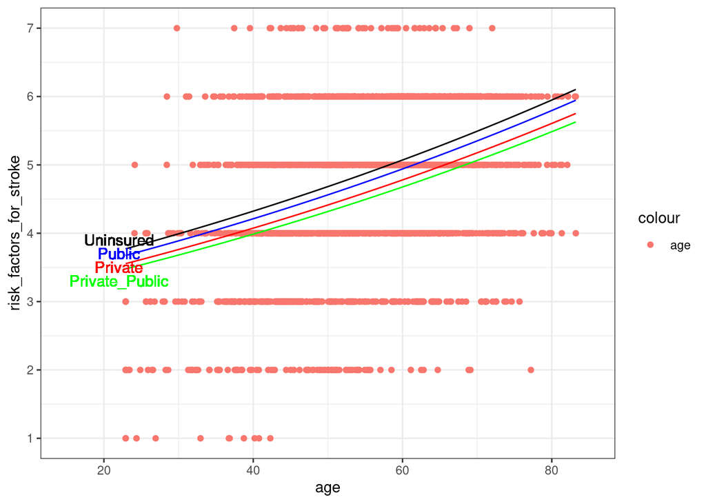

```r
data1 = data1 %>%
mutate(
predPriv = exp(c1[1]+c1[2]*age + c1[3]*1 + c1[6]),
predPub = exp(c1[1]+c1[2]*age + c1[4]*1 + c1[6]),
predPriv_Pub = exp(c1[1]+c1[2]*age + c1[5]*1 + c1[6]),
predUni = exp(c1[1]+c1[2]*age + c1[6])
)

ggplot(data1, aes(x = age, y = risk_factors_for_stroke, color="age")) +
scale_y_continuous(breaks=seq(0,7,1)) +
xlim(15, 85) +
geom_point() +
geom_line(aes(y = predPriv), color = "red") +
geom_line(aes(y = predPub), color = "blue") +
geom_line(aes(y = predPriv_Pub), color = "green") +
geom_line(aes(y = predUni), color = "black") +
geom_text(aes(x = 22, y = 3.9, label = "Uninsured"), color="black", show.legend = FALSE) +
geom_text(aes(x = 22, y = 3.7, label = "Public"), color="blue", show.legend = FALSE) +
geom_text(aes(x = 22, y = 3.5, label = "Private"), color="red", show.legend = FALSE)+
geom_text(aes(x = 22, y = 3.3, label = "Private_Public"), color="green", show.legend = FALSE)+
theme_bw()
```

The graphic confirms the conclusions above. As age increases, the controllable risk factors for stroke increase. On the other hand, people who are privately and publicly insured simultaneously have less controllable risk factors for stroke than another type of insurance and uninsured individuals.